# temp_final-analysis_JAN2025

### Interpret and visualize model results

```r
#to interpret model results

##CTmax
get_model_data(model.4b,type="pred", terms = c("sex.2"))
```

```
## # Predicted values of CTmax.C
##
## sex.2 | Predicted |       95% CI | group_col
## --------------------------------------------
##     1 |     35.17 | 34.62, 35.72 |         1
##     2 |     35.59 | 34.78, 36.40 |         1
##     3 |     35.16 | 34.41, 35.92 |         1
```

```r
##CTmin
get_model_data(model.5b,type="pred", terms = c("sex.2"))
```

```
## # Predicted values of CTmin.C
##
## sex.2 | Predicted |      95% CI | group_col
## -------------------------------------------
##     1 |      9.73 | 9.38, 10.09 |         1
##     2 |      9.81 | 9.29, 10.32 |         1
##     3 |     10.14 | 9.66, 10.62 |         1
```

```r
##Tot temp
get_model_data(model.6b,type="pred", terms = c("sex.2"))
```

```
## # Predicted values of T.tot
##
## sex.2 | Predicted |       95% CI | group_col
## --------------------------------------------
##     1 |     25.44 | 24.80, 26.08 |         1
##     2 |     25.78 | 24.85, 26.72 |         1
##     3 |     25.02 | 24.15, 25.90 |         1
```

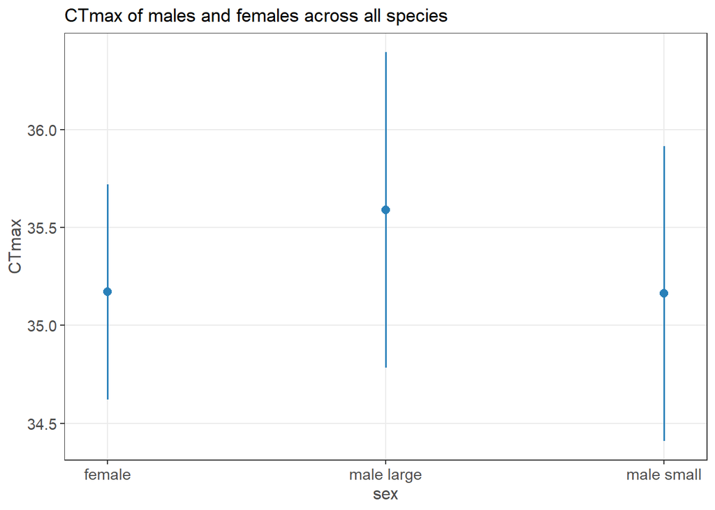

```r
#plot results

##CTmax
set_theme(base = theme_bw(), panel.minor.gridcol = 'white')

##using the type="pred" parameter allows us to visualize how specific terms affect our outcome variable. This will create a graph with sex/mating categories on the x, and CTmax on the y.
CTMAX_results_SW <- plot_model(model.4b,
             type = "pred",
             terms = c("sex.2"),
             colors=c("#2980b9", "#16a085", "#f39c12"),
             axis.title = c("sex", "CTmax"),
             legend.title = c("sex"), title = "CTmax of males and females across all species")

CTMAX_results_SW
```

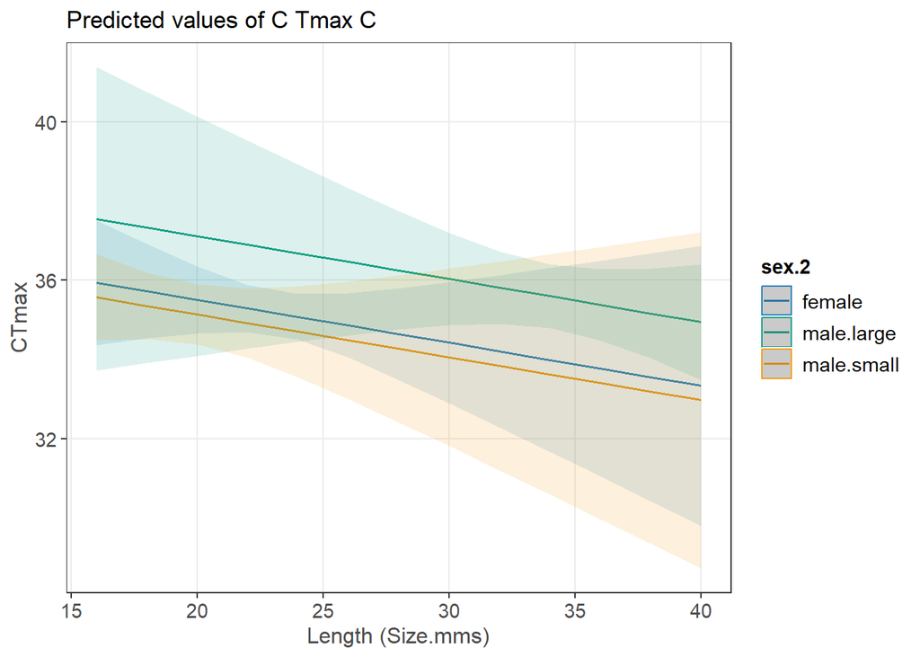

```r
#now lets also include size. This will create a figure with size as the x-axis, ctmax as the y, and three predictor lines for the sexes/mating styles

CTMAX_results2_SW <- plot_model(model.4a,
             type = "pred",
             terms = c("Size.mm", "sex.2"),
             colors=c("#2980b9", "#16a085", "#f39c12"),
             axis.title = c("Length (Size.mms)", "CTmax"),
             legend.title = c("sex.2"))

CTMAX_results2_SW
```

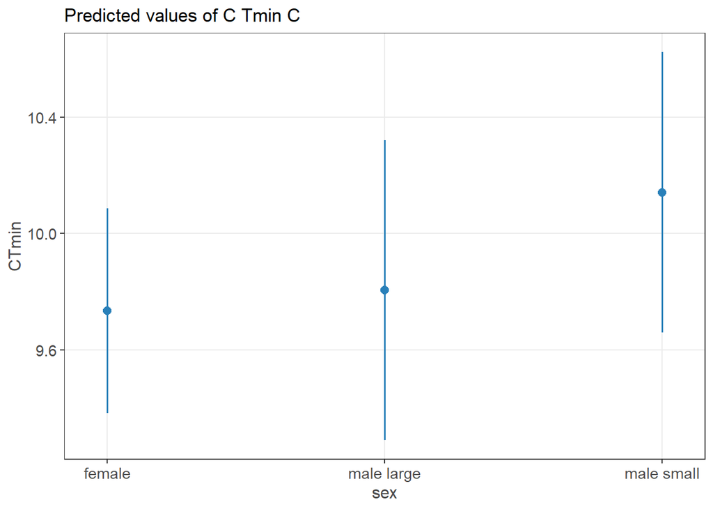

```r
##CTmin

set_theme(base = theme_bw(), panel.minor.gridcol = 'white')

##using the type="pred" parameter allows us to visualize how specific terms affect our outcome variable. This will create a graph with sex/mating categories on the x, and CTmax on the y.
CTMIN_results_SW <- plot_model(model.5b,
             type = "pred",
             terms = c("sex.2"),
             colors=c("#2980b9", "#16a085", "#f39c12"),
             axis.title = c("sex", "CTmin"),
             legend.title = c("sex"))

CTMIN_results_SW
```

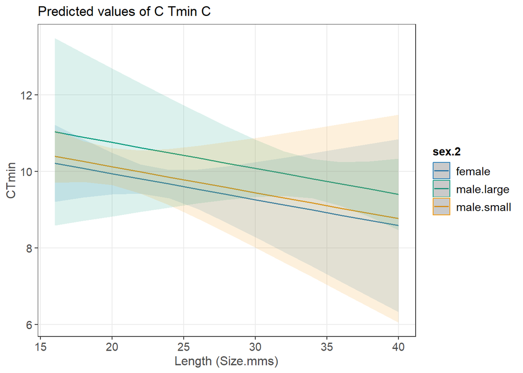

```r
#now lets also include size. This will create a figure with size as the x-axis, ctmax as the y, and three predictor lines for the sexes/mating styles

CTMIN_results2_SW <- plot_model(model.5a,
             type = "pred",
             terms = c("Size.mm", "sex.2"),
             colors=c("#2980b9", "#16a085", "#f39c12"),
             axis.title = c("Length (Size.mms)", "CTmin"),
             legend.title = c("sex.2"))

CTMIN_results2_SW
```

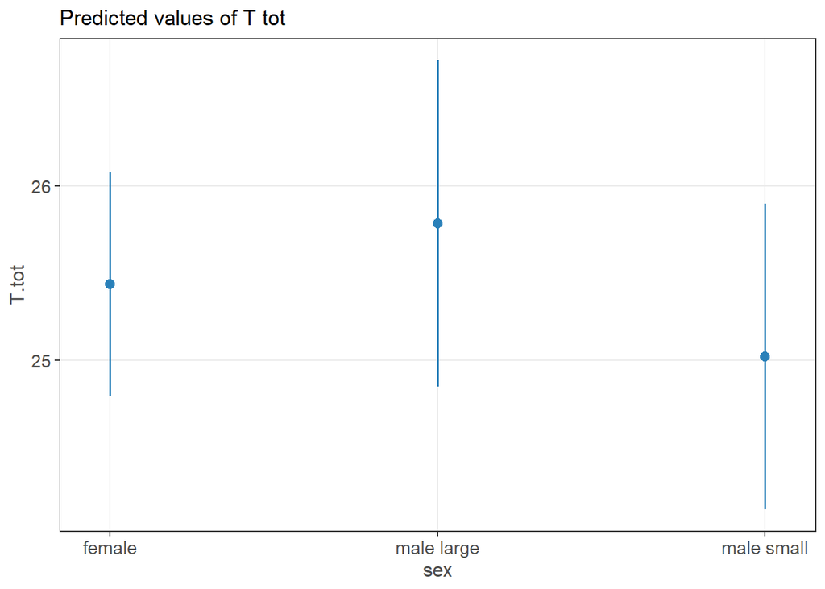

```r
##Tot temp

set_theme(base = theme_bw(), panel.minor.gridcol = 'white')

##using the type="pred" parameter allows us to visualize how specific terms affect our outcome variable. This will create a graph with sex/mating categories on the x, and CTmax on the y.
TTOT_results_SW <- plot_model(model.6b,
             type = "pred",
             terms = c("sex.2"),
             colors=c("#2980b9", "#16a085", "#f39c12"),
             axis.title = c("sex", "T.tot"),
             legend.title = c("sex"))

TTOT_results_SW
```

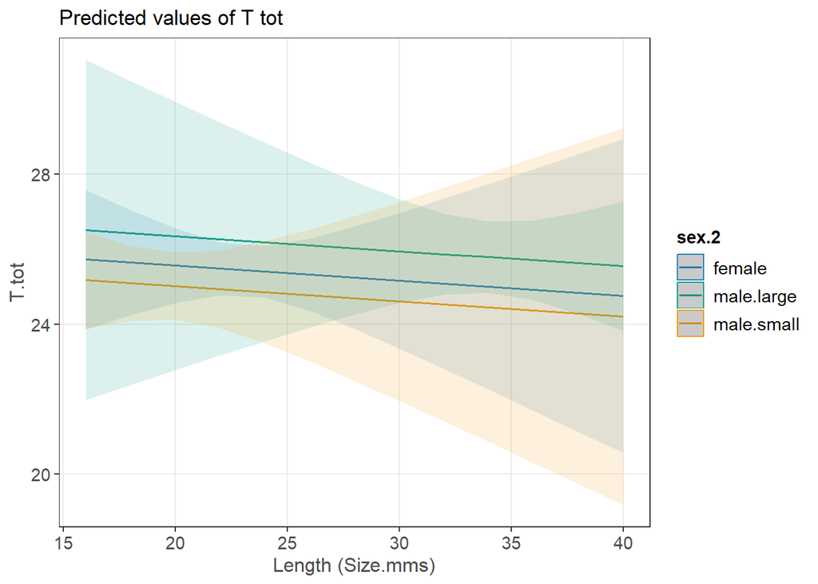

```r
#now lets also include size. This will create a figure with size as the x-axis, ctmax as the y, and three predictor lines for the sexes/mating styles

TTOT_results2_SW <- plot_model(model.6a,
             type = "pred",
             terms = c("Size.mm", "sex.2"),
             colors=c("#2980b9", "#16a085", "#f39c12"),
             axis.title = c("Length (Size.mms)", "T.tot"),
             legend.title = c("sex.2"))

TTOT_results2_SW
```

### Question 2 results

CTMAX - no significant difference in either male type (coercise or courting) and females. - mean around 35.15 deg C

CTMIN - also no sig difference between female and male swordtails for the min temp they can withstand - mean around 9.78 deg C

TTOT - again no sig difference between female and male swordtails for the total temp - mean of 25.4

# Visualizations

This will be a section to create and save all of your figures. Some may be repeats of what you’ve done above, but it’s nice to have it all in one spot. To save a figure as a jpeg/pdf/png etc, use the code below. This will matter most when we figure out what the publisher wants your figures saved as.

< save_plot(filename=image_name.jpg, fig=figure_name, width=30, height=19) > - replace .jpg with .pdf, .png etc to change file format - adjust width and height numbers as needed/wanted

```r
#palatte creation

#' Complete list of palettes
#'
#' Use \code{\link{wes_palette}} to construct palettes of desired length.
#'
#' Color palettes were obtained from various websites include:
#' https://personal.sron.nl/~pault/#sec:qualitative
#' https://davidmathlogic.com/colorblind/#%23648FFF-%23785EF0-%23DC267F-%23FE6100-%23FFB000
#' https://bookdown.org/hneth/ds4psy/ds4psy_files/figure-html/apx-color-define-rgb-1.png
#'
#' @export
friendly_pals <- list(
  bright_seven = c("#4477AA", "#228833", "#AA3377", "#BBBBBB", "#66CCEE", "#CCBB44", "#EE6677"),
  contrast_three = c("#004488", "#BB5566", "#DDAA33"),
  vibrant_seven = c("#0077BB", "#EE7733", "#33BBEE", "#CC3311", "#009988", "#EE3377", "#BBBBBB"),
  muted_nine = c("#332288", "#117733", "#CC6677", "#88CCEE", "#999933", "#882255", "#44AA99", "#DDCC77", "#AA4499"),
  nickel_five = c("#648FFF", "#FE6100", "#785EF0", "#FFB000", "#DC267F"),
  ito_seven = c("#0072B2", "#D55E00", "#009E73", "#CC79A7", "#56B4E9", "#E69F00", "#F0E442"),
  ibm_five = c("#648FFF", "#785EF0", "#DC267F", "#FE6100", "#FFB000"),
  wong_eight = c("#E69F00", "#56B4E9", "#009E73", "#F0E442", "#0072B2", "#D55E00", "#CC79A7", "#000000"),
  tol_eight = c("#332288", "#117733", "#44AA99", "#88CCEE", "#DDCC77", "#CC6677", "#AA4499", "#882255"),
  zesty_four = c("#F5793A", "#A95AA1", "#85C0F9", "#0F2080"),
  retro_four = c("#601A4A", "#EE442F", "#63ACBE", "#F9F4EC")
)

#' A color blind friendly color palette generator
#'
#' Code is based on the wes anderson package https://github.com/karthik/wesanderson
#' These are a handful of color palettes that are color blind friendly.
#'
#' @param n Number of colors desired.
#' @param name Name of desired palette. Choices are:
#'   \code{bright_seven}, \code{contrast_three},  \code{vibrant_seven},
#'   \code{muted_nine}, \code{nickel_five},  \code{ito_eight}
#' @param type Either "continuous" or "discrete". Use continuous if you want
#'   to automatically interpolate between colours.
#'   @importFrom graphics rgb rect par image text
#' @return A vector of colours.
#' @export
#' @keywords colors
#' @examples
#' friendly_pal("bright_seven")
#' friendly_pal("contrast_three")
#' friendly_pal("vibrant_seven")
#' friendly_pal("vibrant_seven", 3)
#'
#' # If you need more colours than normally found in a palette, you
#' # can use a continuous palette to interpolate between existing
#' # colours
#' pal <- friendly_pal(21, name = "muted_nine", type = "continuous")
#' image(volcano, col = pal)
friendly_pal <- function(name, n, type = c("discrete", "continuous")) {
  type <- match.arg(type)

  pal <- friendly_pals[[name]]
  if (is.null(pal))
    stop("Palette not found.")

  if (missing(n)) {
    n <- length(pal)
  }

  if (type == "discrete" && n > length(pal)) {
    stop("Number of requested colors greater than what palette can offer")
  }

  out <- switch(type,
    continuous = grDevices::colorRampPalette(pal)(n),
    discrete = pal[1:n]
  )
  structure(out, class = "palette", name = name)
}
```

## Summary stats

Here we’ll just have some basic summary stats plots. These may be included in supplementary material, but chances are, they’re not informative enough for the main text.

```r
library(ggokabeito) #provides a colorblind friendly color palette
```

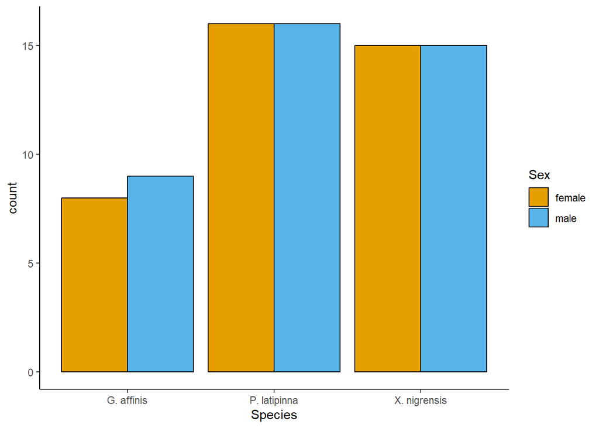

```r
sexINspecies<- ggplot(data=rawTempData, aes(x=Species, fill=Sex)) + geom_bar(color= "black", position=position_dodge())+ theme_classic() + scale_fill_okabe_ito()

sexINspecies
```

## Model visualizations

Copy the visualizations of the final chosen models you performed above.

[figure not shown]

```r
#Question1
##CTMax

###Table
##CTmax_table <- tab_model(model_name, show.reflvl=T, show.intercept=F, p.style="numeric_stars")
##CTmax_table

##CTmin


###Table



##Tottemp


###Table



########################

#Question2

##CTmax




###Table



##CTmin



###Table



##Tottemp
TTOT_results2_SW <- plot_model(model.6a,
             type = "pred",
             terms = c("Size.mm", "sex.2"),
             colors=friendly_pal("contrast_three"),
             line.size = 1,
             axis.title = c("Length (mm)", expression("Total thermal range ("*degree*"C)")),
             legend.labels = c("Male-courting", "Male-coercive", "Female")
             )


TTOT_results2_SW
```

```r
###Table
```

## Species visualizations

### Simple

Here we’ll have the box plots you created beforehand, just as a quick visualization of the sexes within each species.

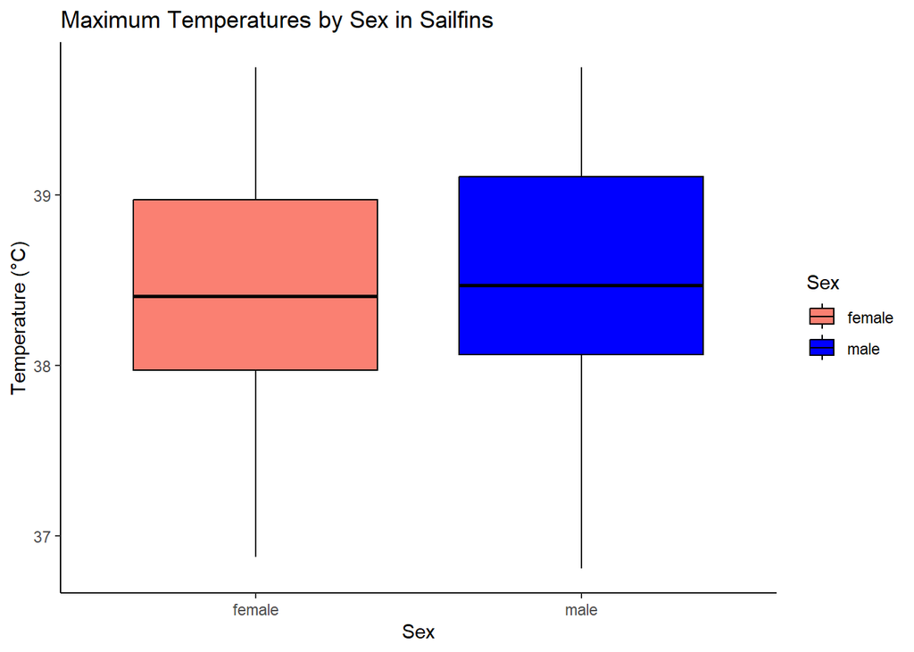

```r
#species data sets
sailfin_1 <- rawTempData[rawTempData$Species =="P. latipinna",]
mosquito_1 <- rawTempData[rawTempData$Species =="G. affinis",]



#male v female max temp in sailfin
sailfin_boxplot1 <- ggplot(data = sailfin_1,
                           aes(x = Sex,
                               y = CTmax.C,
                               fill = Sex)) +
  geom_boxplot(color = "black") +
  labs(
    title = "Maximum Temperatures by Sex in Sailfins",
    x = "Sex",
    y = "Temperature (°C)"
  ) +
  theme_classic() +
  scale_fill_manual(values = c("salmon", "blue"))


print(sailfin_boxplot1)
```

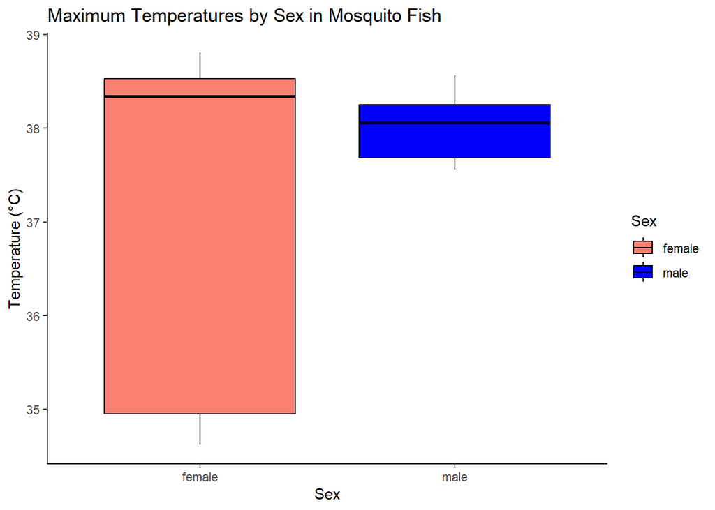

```r
#male v female max temp in mosquitofish
mosquito_boxplot1 <- ggplot(data = mosquito_1,
                           aes(x = Sex,
                               y = CTmax.C,
                               fill = Sex)) +
  geom_boxplot(color = "black") +
  labs(
    title = "Maximum Temperatures by Sex in Mosquito Fish",
    x = "Sex",
    y = "Temperature (°C)"
  ) +
  theme_classic() +
  scale_fill_manual(values = c("salmon", "blue"))

print(mosquito_boxplot1)
```

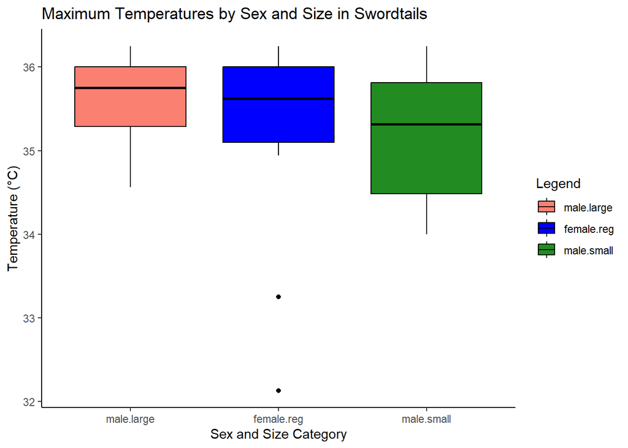

```r
#male v female max temp in swordtail (might want to either create another graph distinguishing between small and large males or just add size category as a shape difference)
swordtail_boxplot4 <- ggplot(data = swordtail_1,
                             aes(x = interaction(Sex, Size.cat),
                                 y = CTmax.C,
                                 fill = interaction(Sex, Size.cat))) +
  geom_boxplot(color = "black") +
  labs(
    title = "Maximum Temperatures by Sex and Size in Swordtails",
    x = "Sex and Size Category",
    y = "Temperature (°C)",
    fill = "Legend"
  ) +
  theme_classic() +
  scale_fill_manual(values = c("salmon", "blue", "forestgreen"))

print(swordtail_boxplot4)
```

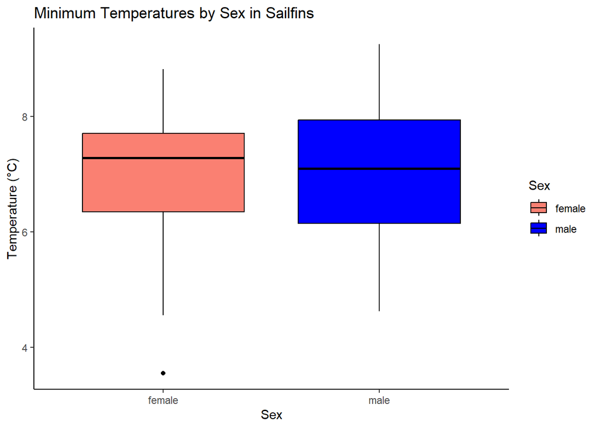

```r
#male v female min temp in sailfin
sailfin_boxplot2 <- ggplot(data = sailfin_1,
                           aes(x = Sex,
                               y = CTmin.C,
                               fill = Sex)) +
  geom_boxplot(color = "black") +
  labs(
    title = "Minimum Temperatures by Sex in Sailfins",
    x = "Sex",
    y = "Temperature (°C)"
  ) +
  theme_classic() +
  scale_fill_manual(values = c("salmon", "blue"))

print(sailfin_boxplot2)
```

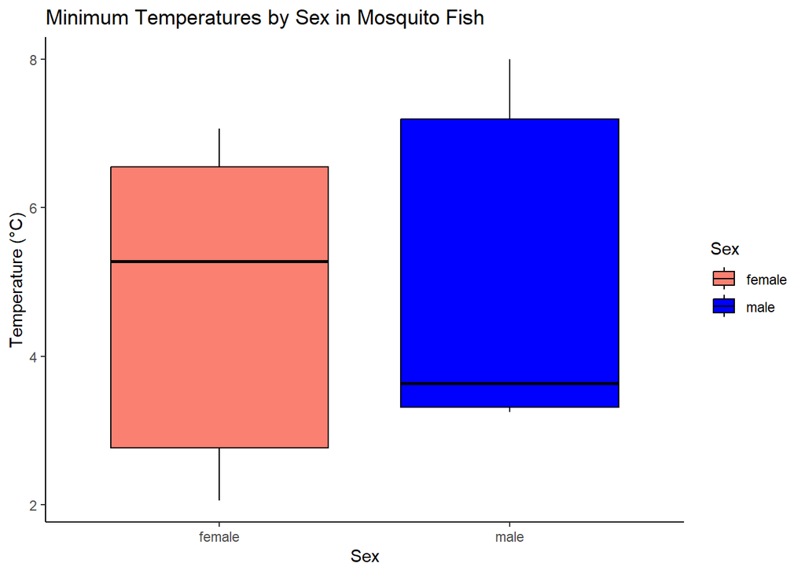

```r
#male v female min temp in mosquitofish
mosquito_boxplot2 <- ggplot(data = mosquito_1,
                           aes(x = Sex,
                               y = CTmin.C,
                               fill = Sex)) +
  geom_boxplot(color = "black") +
  labs(
    title = "Minimum Temperatures by Sex in Mosquito Fish",
    x = "Sex",
    y = "Temperature (°C)"
  ) +
  theme_classic() +
  scale_fill_manual(values = c("salmon", "blue"))

print(mosquito_boxplot2)
```

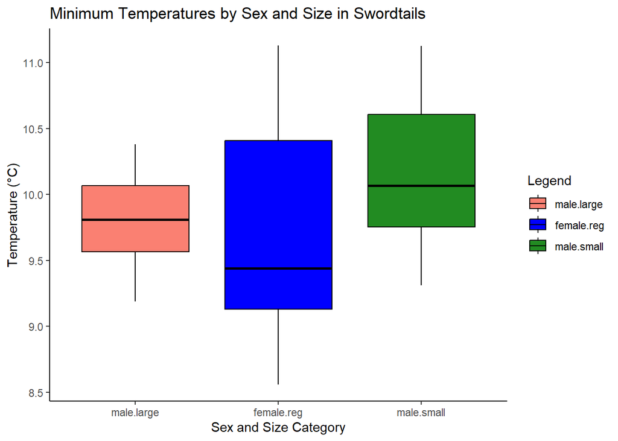

```r
#male v female min temp in swordtail (might want to either create another graph distinguishing between small and large males or just add size category as a shape difference)
swordtail_boxplot5 <- ggplot(data = swordtail_1,
                             aes(x = interaction(Sex, Size.cat),
                                 y = CTmin.C,
                                 fill = interaction(Sex, Size.cat))) +
  geom_boxplot(color = "black") +
  labs(
    title = "Minimum Temperatures by Sex and Size in Swordtails",
    x = "Sex and Size Category",
    y = "Temperature (°C)",
    fill = "Legend"
  ) +
  theme_classic() +
  scale_fill_manual(values = c("salmon", "blue", "forestgreen"))

print(swordtail_boxplot5)
```

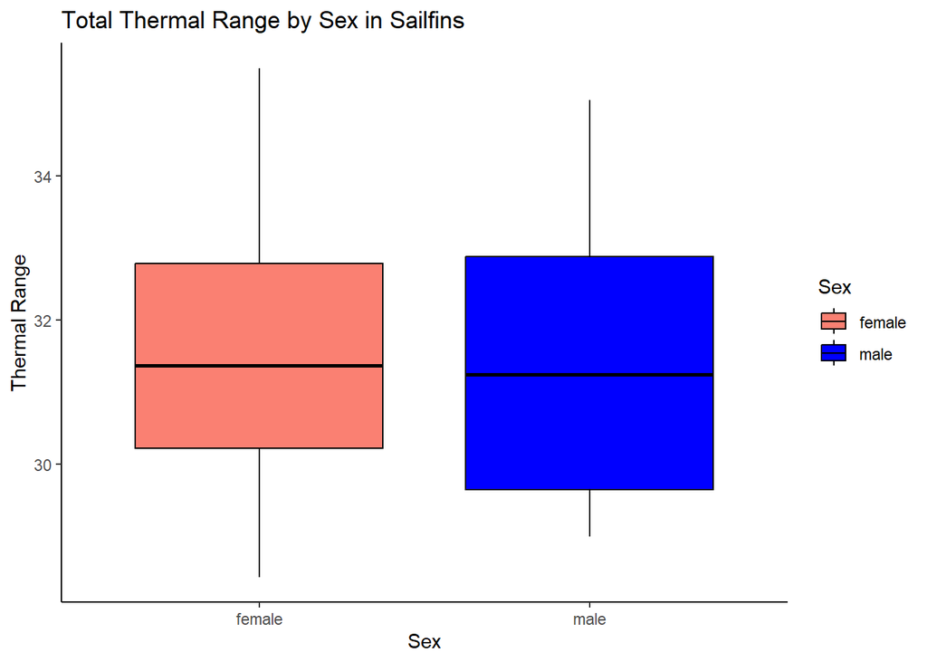

```r
#male v female tot temp in sailfin
sailfin_boxplot3 <- ggplot(data = sailfin_1,
                           aes(x = Sex,
                               y = T.tot,
                               fill = Sex)) +
  geom_boxplot(color = "black") +
  labs(
    title = "Total Thermal Range by Sex in Sailfins",
    x = "Sex",
    y = "Thermal Range"
  ) +
  theme_classic() +
  scale_fill_manual(values = c("salmon", "blue"))

print(sailfin_boxplot3)
```

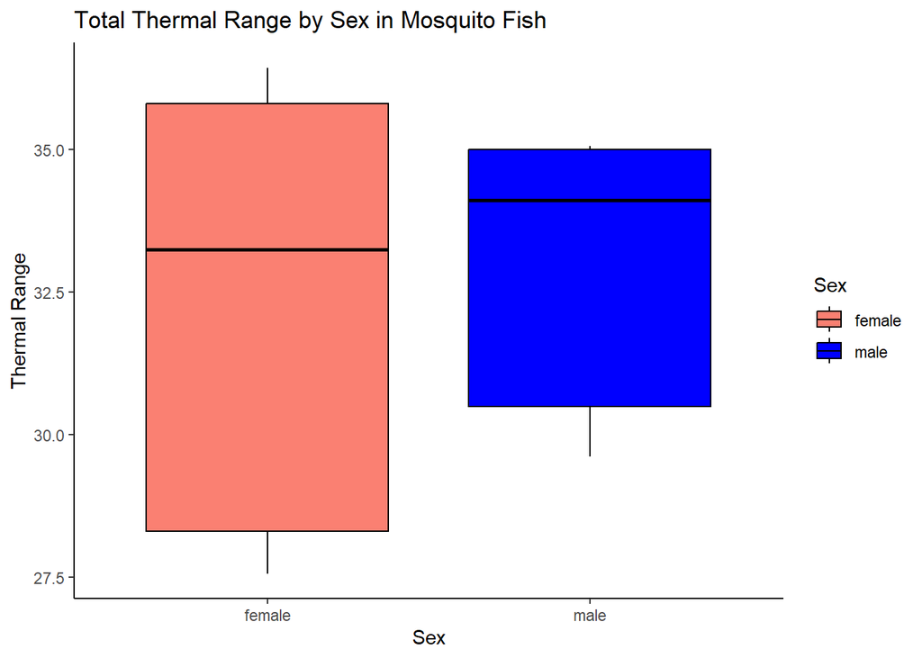

```r
#male v female tot temp in mosquitofish
mosquito_boxplot3 <- ggplot(data = mosquito_1,
                           aes(x = Sex,
                               y = T.tot,
                               fill = Sex)) +
  geom_boxplot(color = "black") +
  labs(
    title = "Total Thermal Range by Sex in Mosquito Fish",
    x = "Sex",
    y = "Thermal Range"
  ) +
  theme_classic() +
  scale_fill_manual(values = c("salmon", "blue"))

print(mosquito_boxplot3)
```

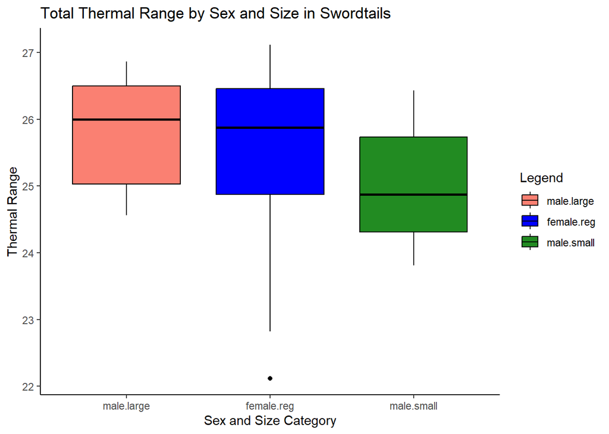

```r
#male v female tot temp in swordtail (might want to either create another graph distinguishing between small and large males or just add size category as a shape difference)
swordtail_boxplot6 <- ggplot(data = swordtail_1,
                             aes(x = interaction(Sex, Size.cat),
                                 y = T.tot,
                                 fill = interaction(Sex, Size.cat))) +
  geom_boxplot(color = "black") +
  labs(
    title = "Total Thermal Range by Sex and Size in Swordtails",
    x = "Sex and Size Category",
    y = "Thermal Range",
    fill = "Legend"
  ) +
  theme_classic() +
  scale_fill_manual(values = c("salmon", "blue", "forestgreen"))

print(swordtail_boxplot6)
```

### Complex

Here we’ll include size as a variable in our figures as well. The final figures should have size as the x-axis, the temp (max, min, or total) as the y-axis, and two regression lines for the sex (I’ll send you a photo so you know what it should look like). For swordtails, you’ll have one graph that is just male and female regression lines, then a second graph for male-courting, male-coercive, and female, so three regression lines.

NOTE: may not actually need, depending on how the model graphs come out. We’ll come back to this after you run the model plots.